# CommunityContribution

## Aim

As part of community contribution we aim to analyze the crime frequency in the districts surrounding Columbia University. As international students, we were very concerned about the safety of the locality we wished to reside in. Our project helps in identifying areas of high crime and thereby help students with house hunting as well as getting around the area near Columbia University.

## Procedure

We begin by first installing geopandas. This library is required to work with geospatial data.

```python
pip install geopandas
```

```
     |████████████████████████████████| 1.0 MB 4.3 MB/s eta 0:00:01
     |████████████████████████████████| 1.2 MB 2.9 MB/s eta 0:00:01
     |████████████████████████████████| 19.3 MB 23.9 MB/s eta 0:00:01
     |████████████████████████████████| 7.5 MB 6.8 MB/s eta 0:00:011
```

```python
pip install folium
```

```
     |████████████████████████████████| 94 kB 2.7 MB/s eta 0:00:011
```

```python
import pandas as pd
import numpy as np
import json
import folium
import geopandas as gpd
import branca.colormap as cm
import seaborn as sns
import matplotlib.pyplot as plt
```

The data we collected from https://data.cityofnewyork.us/Public-Safety/NYPD-Complaint-Data-Historic/qgea-i56i consists of 7.8 million rows. It included all crimes from all the precincts in the city of New York. We only need information from the precincts surrounding Columbia University. We filtered the data this way to get a dataframe having 269k rows.

```python
df1=pd.read_csv('all years')
```

```python
len(df1)
```

```
269811
```

The data also had crimes from 1980 but there existed missing values. Moreover, we only wanted to include the last decade in our analysis. This lets us get a much better and accurate idea of the safety of the locality. After excluding all the data before 2009, we were left with 189k rows.

```python
df1=df1[df1['CMPLNT_FR_DT']>2009]
```

```python
len(df1)
```

```
189398
```

The first part of our assignment involves a bit of data visualization to gain useful insights from the crime data.

```python
df2=pd.read_csv('NYPD_Complaint_Data_Historic.csv')
```

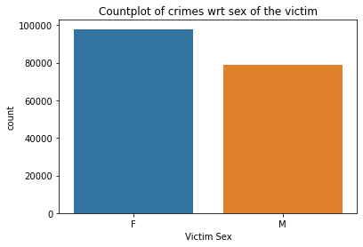

```python
stk_list=[24,28,26,30]
df2 = df2[df2['ADDR_PCT_CD'].notna()]
df2=df2[df2['ADDR_PCT_CD'].isin(stk_list)]
df2.reset_index(drop = 'TRUE')
df2 = df2[["CMPLNT_FR_DT",
          "CMPLNT_FR_TM",
          "ADDR_PCT_CD",
          "RPT_DT",
          "KY_CD",
          "OFNS_DESC",
          "BORO_NM",
          "PARKS_NM",
          "X_COORD_CD",
          "Y_COORD_CD",
          "Latitude",
          "Longitude",
          "Lat_Lon",
          "VIC_SEX"]]
df_sex = df2[df2["VIC_SEX"].isin(['M', 'F'])].reset_index()
plt.title('Countplot of crimes wrt sex of the victim')
sns.countplot(df_sex["VIC_SEX"])
plt.xlabel('Victim Sex')
plt.show()
```

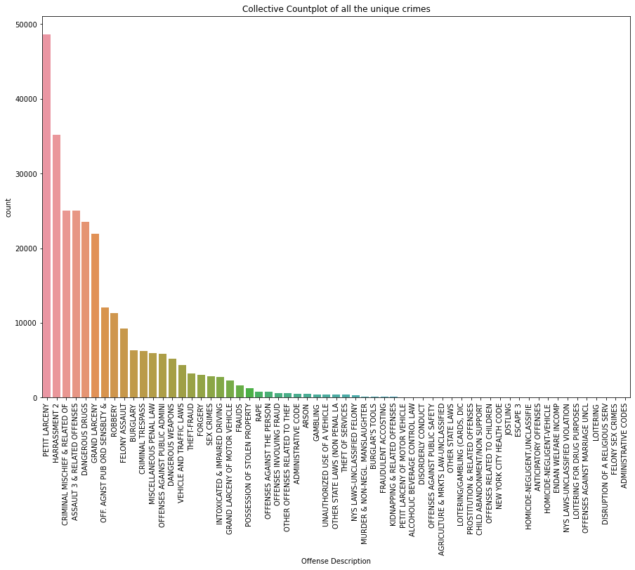

```python
plt.figure(figsize=(15,10))
sns.countplot(df2["OFNS_DESC"], order = df2["OFNS_DESC"].value_counts().index)
plt.xticks(rotation=90)
plt.title('Collective Countplot of all the unique crimes')
plt.xlabel('Offense Description')
plt.show()
```

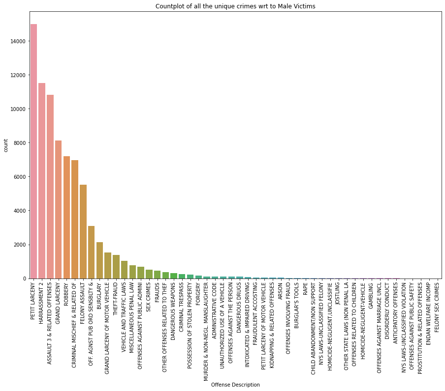

```python
df_sex = df2[df2["VIC_SEX"].isin(['M'])].reset_index()
plt.figure(figsize=(15,10))
sns.countplot(df_sex["OFNS_DESC"], order = df_sex["OFNS_DESC"].value_counts().index)
plt.xticks(rotation=90)
plt.title('Countplot of all the unique crimes wrt to Male Victims')
plt.xlabel('Offense Description')
plt.show()
```

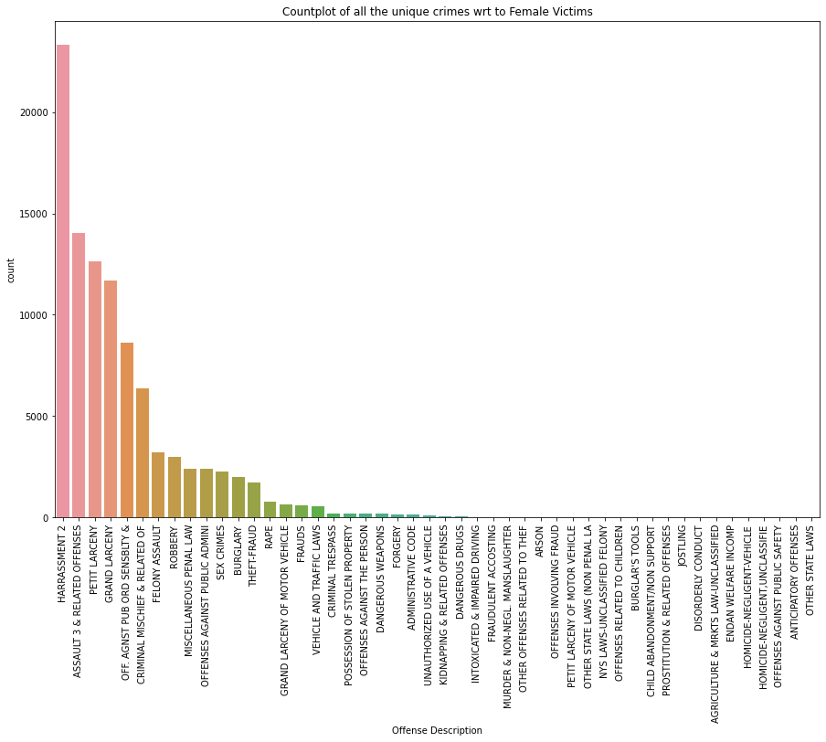

```python
df_sex = df2[df2["VIC_SEX"].isin(['F'])].reset_index()
plt.figure(figsize=(15,10))
sns.countplot(df_sex["OFNS_DESC"], order = df_sex["OFNS_DESC"].value_counts().index)
plt.xticks(rotation=90)
plt.title('Countplot of all the unique crimes wrt to Female Victims')
plt.xlabel('Offense Description')
plt.show()
```

In order to plot the data on a chloropleth map, we need the geographical polygons describing the outline of each precinct. We obtained a geojson file from https://data.cityofnewyork.us/Public-Safety/Police-Precincts/78dh-3ptz for this purpose. Again, we only get the precincts we require which are 24, 28, 26 and 30. We only keep the precinct and geometry column for simplicity

```python
stk_list=['24','28','26','30']
nil = gpd.read_file('Police Precincts.geojson')
nil=nil[nil['precinct'].isin(stk_list)]
nil
```

|  | precinct | shape_area | shape_leng | geometry |
| --- | --- | --- | --- | --- |
| 16 | 24 | 25479873.3684 | 20706.9190759 | MULTIPOLYGON (((-73.95965 40.80116, -73.95856 ... |
| 18 | 26 | 23836010.5268 | 23938.4964876 | MULTIPOLYGON (((-73.94608 40.82126, -73.94640 ... |
| 19 | 28 | 15289544.596 | 17098.9870878 | MULTIPOLYGON (((-73.94132 40.80771, -73.94177 ... |
| 20 | 30 | 18845037.7959 | 21645.146297 | MULTIPOLYGON (((-73.94017 40.83038, -73.93963 ... |

```python
nil=nil[['precinct','geometry']]
```

We grouped the crimes in our dataframe by precinct and then took a count. We also substituted the crime column for each precinct by each precincts contribution to the total crime in terms of a percentage value.

```python
x=df1.groupby('ADDR_PCT_CD').size().to_frame()
x.reset_index(inplace=True)
x=x.rename(columns={0: "crimes",'ADDR_PCT_CD':'precinct'})
x['crimes']=x['crimes']/x['crimes'].sum()*100
```

To center our map in our desired region, we calculate the centroid of all the regions.

```python
x_map=nil.centroid.x.mean()
y_map=nil.centroid.y.mean()
print(x_map,y_map)
```

```
-73.95739234564192 40.80957562817518
```

We then add our crime values to the dataset with the geospatial data.

```python
nil['crimes']=x['crimes'].values
```

Given below is an example of a polygon used to create the Chloropleth map.

```python
nil['geometry'][16]
```

[output not shown]

The code below creates the map into which we add our data to create the Chloropleth map.

```python
mymap = folium.Map(location=[y_map, x_map], zoom_start=14,tiles=None)
folium.TileLayer('CartoDB positron',name="Light Map",control=False).add_to(mymap)
mymap
```

Make this Notebook Trusted to load map: File -> Trust Notebook

[interactive chart not shown]

The map is then generated coloring each precinct by the degree of crime

```python
myscale = (nil['crimes'].quantile((0,0.1,0.75,0.9,0.98,1))).tolist()
mymap.choropleth(
 geo_data=nil,
 name='Choropleth',
 data=nil,
 columns=['precinct','crimes'],
 key_on="feature.properties.precinct",
 fill_color='YlOrRd',
 threshold_scale=myscale,
 fill_opacity=1,
 line_opacity='Crime %',
 smooth_factor=0
)
mymap
```

Make this Notebook Trusted to load map: File -> Trust Notebook

[interactive chart not shown]

The map above is not particulary descriptive. We cannot really isolate each precinct and neither get a clear crime % value. To get a better visualization, we made the map interactive. When the user's cursor hovers over a region, they can see the precinct number as well as the crime percentage of the area.

```python
style_function = lambda x: {'fillColor': '#ffffff',
                            'color':'#000000',
                            'fillOpacity': 0.1,
                            'weight': 0.1}
highlight_function = lambda x: {'fillColor': '#000000',
                                'color':'#000000',
                                'fillOpacity': 0.50,
                                'weight': 0.1}
NIL = folium.features.GeoJson(
    nil,
    style_function=style_function,
    control=False,
    highlight_function=highlight_function,
    tooltip=folium.features.GeoJsonTooltip(
        fields=['precinct','crimes'],
        aliases=['Precinct: ','Crime %: '],
        style=("background-color: white; color: #333333; font-family: arial; font-size: 12px; padding: 10px;")
    )
)
mymap.add_child(NIL)
mymap.keep_in_front(NIL)
folium.LayerControl().add_to(mymap)
mymap
```

Make this Notebook Trusted to load map: File -> Trust Notebook

[interactive chart not shown]